# Stats 412 HW 1

Chris Meade

4/23/2018

### Setup

```r
war <- read.csv("http://www.stat.cmu.edu/~cshalizi/uADA/15/hw/06/ch.csv", row.names = 1)
```

### Part 1. - Estimation

```r
fit1 <- glm(start ~ I(exports^2) +
              schooling +
              growth +
              peace +
              concentration +
              lnpop +
              fractionalization +
              dominance,
            family = binomial,
            data = war)

summary(fit1)
```

```
##
## Call:
## glm(formula = start ~ I(exports^2) + schooling + growth + peace +
##     concentration + lnpop + fractionalization + dominance, family = binomial,
##     data = war)
##
## Deviance Residuals:
##     Min       1Q   Median       3Q      Max
## -1.2443  -0.3704  -0.2290  -0.1354   2.9791
##
## Coefficients:
##                     Estimate Std. Error z value Pr(>|z|)
## (Intercept)       -7.470e+00  2.046e+00  -3.650 0.000262 ***
## I(exports^2)       2.799e+00  1.871e+00   1.496 0.134549
## schooling         -2.388e-02  8.685e-03  -2.750 0.005964 **
## growth            -1.364e-01  4.336e-02  -3.147 0.001650 **
## peace             -4.089e-03  1.097e-03  -3.729 0.000192 ***
## concentration     -1.563e+00  9.220e-01  -1.696 0.089960 .
## lnpop              4.777e-01  1.249e-01   3.823 0.000132 ***
## fractionalization -9.910e-05  8.231e-05  -1.204 0.228559
## dominance          5.375e-01  3.451e-01   1.557 0.119395
## ---
## Signif. codes:  0 '***' 0.001 '**' 0.01 '*' 0.05 '.' 0.1 ' ' 1
##
## (Dispersion parameter for binomial family taken to be 1)
##
##     Null deviance: 337.73  on 687  degrees of freedom
## Residual deviance: 270.83  on 679  degrees of freedom
##   (600 observations deleted due to missingness)
## AIC: 288.83
##
## Number of Fisher Scoring iterations: 7
```

From the summary given above, we can see that the intercept, `schooling`, `growth`, `peace`, and `lnpop` are significant at the `0.05` percent significance level.

### Part 2. - Interpretation

#### 1.)

Probability of civil war for India in 1975:

```r
observation <- war[500,]
probability <- predict(fit1, observation, type = 'response')
probability
```

```
##       500
## 0.4268744
```

The probability for a civil war breaking out in India in 1975 is `0.4268744` according to our model.

Now we look at the same data, except with the male secondary school enrollment rate 30 points higher.

```r
observation <- war[500,]
observation$schooling <- observation$schooling + 30
probability <- predict(fit1, observation, type = 'response')
probability
```

```
##       500
## 0.2667712
```

The probability of civil war breaking out sharply decreases to `0.2667712`.

Finally, we look at a country just like India in 1975, except that the ratio of commodity exports to GDP was 0.1 higher.

```r
observation <- war[500,]
observation$exports <- observation$exports + .1
probability <- predict(fit1, observation, type = 'response')
probability
```

```
##       500
## 0.4373147
```

The probability of civil war is now `0.4373147`.

#### 2.)

We first get the data for Nigeria in 1965 and make a prediction.

```r
observation <- war[802,]
probability <- predict(fit1, observation, type = 'response')
probability
```

```
##       802
## 0.1397182
```

Our predicted probability is only `0.1397182`. Now we look at the same data, but with male secondary school enrollment rate 30 points higher.

```r
observation <- war[802,]
observation$schooling <- observation$schooling + 30
probability <- predict(fit1, observation, type = 'response')
probability
```

```
##        802
## 0.07350307
```

Predicted probability of civil war drops to `0.07350307`. Finally, we look at the original Nigeria data from 1965 but with the ratio of commodity exports to GDP 0.1 higher.

```r
observation <- war[802,]
observation$exports <- observation$exports + .1
probability <- predict(fit1, observation, type = 'response')
probability
```

```
##       802
## 0.1517707
```

The probability of civil war for a country with this data would be `0.1517707`.

#### 3.)

Because we utilize the nonlinear logit function in logistic regression, the probabilities’ rate of change is different along different areas of the curve. It is greatest in the center and flattens out around `0` and `1`. Therefore, although we make the same changes to both observations, the resulting change in probability is different for each observation as they essentially lie along different points in the curve that may be stepper or flatter than the other.

### Part 3. - Confusion

#### 1.

```r
library(caret)
probabilities <- predict(fit1, war, type = 'response')
predictionsLOG <- ifelse(probabilities >= .5, 1, 0)
confusionMatrix(war$start, predictionsLOG)
```

```
## Confusion Matrix and Statistics
##
##           Reference
## Prediction   0   1
##          0 640   2
##          1  44   2
##
##                Accuracy : 0.9331
##                  95% CI : (0.9118, 0.9506)
##     No Information Rate : 0.9942
##     P-Value [Acc > NIR] : 1
##
##                   Kappa : 0.0701
##  Mcnemar's Test P-Value : 1.493e-09
##
##             Sensitivity : 0.93567
##             Specificity : 0.50000
##          Pos Pred Value : 0.99688
##          Neg Pred Value : 0.04348
##              Prevalence : 0.99419
##          Detection Rate : 0.93023
##    Detection Prevalence : 0.93314
##       Balanced Accuracy : 0.71784
##
##        'Positive' Class : 0
##
```

#### 2.

The model’s accuracy is `0.9331`, so its misclassification rate is `1-0.9331=0.0669`.

#### 3.

```r
mean(war$start == 0, na.rm = T)
```

```
## [1] 0.933162
```

If a pundit were to precict `no war` for every observation on the dataset, they would be accruate `0.933162` percent of the time.

Since the model almost always predicts `0`, the pundits accuracy is `0.994186` on the set of predictions.

```r
mean(predictionsLOG == 0, na.rm = T)
```

```
## [1] 0.994186
```

## 4. - Comparison

#### 1.

We must first preprocess the data to deal with missing values in to fit the `lda()` and `qda()` models. I choose to remove all observations with a missing feature. However, there are other methods that could be utilized to deal with these missing values, such as imputation.

We now fit the LDA model.

```r
library(tidyr)
war2 <- war %>% drop_na()
library(MASS)
fitLDA <- lda(factor(start) ~ I(exports^2) +
              schooling +
              growth +
              peace +
              concentration +
              lnpop +
              fractionalization +
              dominance,
              data = war2)

fitLDA
```

```
## Call:
## lda(factor(start) ~ I(exports^2) + schooling + growth + peace +
##     concentration + lnpop + fractionalization + dominance, data = war2)
##
## Prior probabilities of groups:
##          0          1
## 0.93313953 0.06686047
##
## Group means:
##   I(exports^2) schooling     growth    peace concentration    lnpop
## 0   0.04505594  45.64548 1.73095794 357.7850     0.6038349 15.68224
## 1   0.04127454  28.34783 0.04384783 204.2826     0.5762391 16.58465
##   fractionalization dominance
## 0          1764.882 0.4376947
## 1          2146.696 0.4565217
##
## Coefficients of linear discriminants:
##                             LD1
## I(exports^2)       1.858921e+00
## schooling         -6.409013e-03
## growth            -1.415680e-01
## peace             -4.496371e-03
## concentration     -1.098846e+00
## lnpop              3.053406e-01
## fractionalization -6.507113e-05
## dominance          3.137136e-01
```

```r
classLDA <- predict(fitLDA, war2)$class
mean(war2$start == classLDA)
```

```
## [1] 0.934593
```

Our LDA model achieves an accuracy of `0.934593`.

#### 2.

Next we fit the QDA model.

```r
fitQDA <- qda(factor(start) ~ I(exports^2) +
              schooling +
              growth +
              peace +
              concentration +
              lnpop +
              fractionalization +
              dominance,
              data = war2,
              na.action = na.omit)

fitQDA
```

```
## Call:
## qda(factor(start) ~ I(exports^2) + schooling + growth + peace +
##     concentration + lnpop + fractionalization + dominance, data = war2,
##     na.action = na.omit)
##
## Prior probabilities of groups:
##          0          1
## 0.93313953 0.06686047
##
## Group means:
##   I(exports^2) schooling     growth    peace concentration    lnpop
## 0   0.04505594  45.64548 1.73095794 357.7850     0.6038349 15.68224
## 1   0.04127454  28.34783 0.04384783 204.2826     0.5762391 16.58465
##   fractionalization dominance
## 0          1764.882 0.4376947
## 1          2146.696 0.4565217
```

```r
classQDA <- predict(fitQDA, war2)$class
mean(war2$start == classQDA)
```

```
## [1] 0.9273256
```

The QDA model acheives a slightly lower accuracy, `0.9273256`.

#### 3.

All three models have almost the exact same accuracy in classifying the dataset. This probably stems from the large class imbalance in the `start` variable, as all but `78` observations are `0`’s

## 5. - ROC

```r
library(pROC)
roc1 = roc(war$start, predictionsLOG)
roc2 = roc(war2$start, as.numeric(classLDA))
roc3 = roc(war2$start, as.numeric(classQDA))

auc(roc1)
```

```
## Area under the curve: 0.5202
```

```r
auc(roc2)
```

```
## Area under the curve: 0.5512
```

```r
auc(roc3)
```

```
## Area under the curve: 0.6482
```

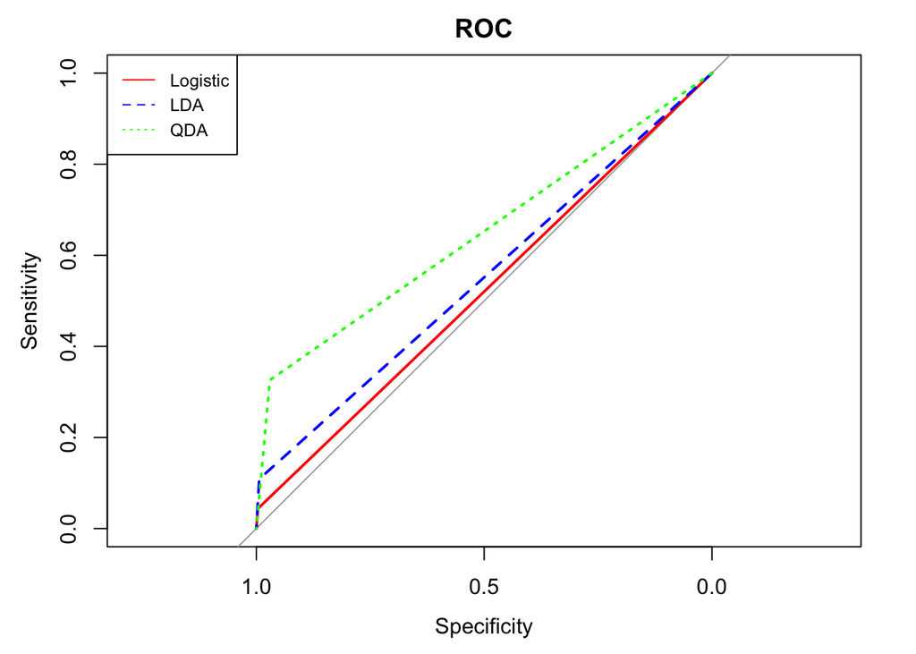

```r
plot(roc1, col = "red", lty =1, main = "ROC")
plot(roc2, col = "blue", lty = 2, add = TRUE)
plot(roc3, col = "green", lty = 3, add = TRUE)
legend("topleft", legend=c("Logistic", "LDA", "QDA"),
       col=c("red", "blue", "green"), lty=1:3, cex=0.8)
```

Based on these ROC curves, it seems that the QDA model achieves the highest AUC score, indicating that it may be the best model despite having a slightly lower accuracy than the others.

## 6. - More Logistic Regression

```r
library(ggplot2)
y<- c(0,0,0,0,1,1,1,1)
x1<-c(1,2,3,3,5,6,10,11)
x2<-c(3,2,-1,-1,2,4,1,0)
df <- data.frame(x1,x2,y)

fitLOG <- glm(y ~ x1 + x2, family = binomial)
```

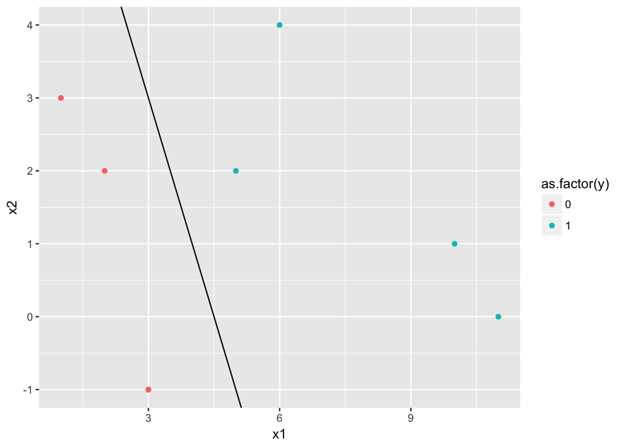

```r
ggplot(df, aes(x = x1, y = x2, color = as.factor(y))) +
  geom_point() +
  geom_abline(slope= -2, intercept = 9)
```